# CAR-INSURANCE

###### Importing required packages

```python
#Libraries to handle the data
import pandas as pd  #for dealing with dataframes
import numpy as np   #for better numerical operations
```

###### Preparing a dataframe

```python
instrain = pd.read_csv('train.csv')
instest = pd.read_csv('test.csv')
```

###### Getting the shape

```python
print("Train data dimensions: ", instrain.shape)
print("Test data dimensions: ", instest.shape)
```

```
Train data dimensions:  (188318, 132)
Test data dimensions:  (125546, 131)
```

```python
instrain.head()
```

|  | id | cat1 | cat2 | cat3 | cat4 | cat5 | cat6 | cat7 | cat8 | cat9 | ... | cont6 | cont7 | cont8 | cont9 | cont10 | cont11 | cont12 | cont13 | cont14 | loss |
| --- | --- | --- | --- | --- | --- | --- | --- | --- | --- | --- | --- | --- | --- | --- | --- | --- | --- | --- | --- | --- | --- |
| 0 | 1 | A | B | A | B | A | A | A | A | B | ... | 0.718367 | 0.335060 | 0.30260 | 0.67135 | 0.83510 | 0.569745 | 0.594646 | 0.822493 | 0.714843 | 2213.18 |
| 1 | 2 | A | B | A | A | A | A | A | A | B | ... | 0.438917 | 0.436585 | 0.60087 | 0.35127 | 0.43919 | 0.338312 | 0.366307 | 0.611431 | 0.304496 | 1283.60 |
| 2 | 5 | A | B | A | A | B | A | A | A | B | ... | 0.289648 | 0.315545 | 0.27320 | 0.26076 | 0.32446 | 0.381398 | 0.373424 | 0.195709 | 0.774425 | 3005.09 |
| 3 | 10 | B | B | A | B | A | A | A | A | B | ... | 0.440945 | 0.391128 | 0.31796 | 0.32128 | 0.44467 | 0.327915 | 0.321570 | 0.605077 | 0.602642 | 939.85 |
| 4 | 11 | A | B | A | B | A | A | A | A | B | ... | 0.178193 | 0.247408 | 0.24564 | 0.22089 | 0.21230 | 0.204687 | 0.202213 | 0.246011 | 0.432606 | 2763.85 |

5 rows × 132 columns

```python
instest.head()
```

|  | id | cat1 | cat2 | cat3 | cat4 | cat5 | cat6 | cat7 | cat8 | cat9 | ... | cont5 | cont6 | cont7 | cont8 | cont9 | cont10 | cont11 | cont12 | cont13 | cont14 |
| --- | --- | --- | --- | --- | --- | --- | --- | --- | --- | --- | --- | --- | --- | --- | --- | --- | --- | --- | --- | --- | --- |
| 0 | 4 | A | B | A | A | A | A | A | A | B | ... | 0.281143 | 0.466591 | 0.317681 | 0.61229 | 0.34365 | 0.38016 | 0.377724 | 0.369858 | 0.704052 | 0.392562 |
| 1 | 6 | A | B | A | B | A | A | A | A | B | ... | 0.836443 | 0.482425 | 0.443760 | 0.71330 | 0.51890 | 0.60401 | 0.689039 | 0.675759 | 0.453468 | 0.208045 |
| 2 | 9 | A | B | A | B | B | A | B | A | B | ... | 0.718531 | 0.212308 | 0.325779 | 0.29758 | 0.34365 | 0.30529 | 0.245410 | 0.241676 | 0.258586 | 0.297232 |
| 3 | 12 | A | A | A | A | B | A | A | A | A | ... | 0.397069 | 0.369930 | 0.342355 | 0.40028 | 0.33237 | 0.31480 | 0.348867 | 0.341872 | 0.592264 | 0.555955 |
| 4 | 15 | B | A | A | A | A | B | A | A | A | ... | 0.302678 | 0.398862 | 0.391833 | 0.23688 | 0.43731 | 0.50556 | 0.359572 | 0.352251 | 0.301535 | 0.825823 |

5 rows × 131 columns

###### Duplicate of the data

```python
instrain[instrain.duplicated()]
```

|  | id | cat1 | cat2 | cat3 | cat4 | cat5 | cat6 | cat7 | cat8 | cat9 | ... | cont6 | cont7 | cont8 | cont9 | cont10 | cont11 | cont12 | cont13 | cont14 | loss |
| --- | --- | --- | --- | --- | --- | --- | --- | --- | --- | --- | --- | --- | --- | --- | --- | --- | --- | --- | --- | --- | --- |

0 rows × 132 columns

```python
instest[instest.duplicated()]
```

|  | id | cat1 | cat2 | cat3 | cat4 | cat5 | cat6 | cat7 | cat8 | cat9 | ... | cont5 | cont6 | cont7 | cont8 | cont9 | cont10 | cont11 | cont12 | cont13 | cont14 |
| --- | --- | --- | --- | --- | --- | --- | --- | --- | --- | --- | --- | --- | --- | --- | --- | --- | --- | --- | --- | --- | --- |

0 rows × 131 columns

###### Information of the varibles and datatypes of different columns

```python
def ins_data(data):
    return pd.DataFrame({"Datatypes":data.dtypes,"No of unique data":data.apply(lambda x: x.nunique(),axis=0),
                        "Levels":data.apply(lambda x: str(x.unique()),axis = 0),"Null_values":data.isnull().sum(),"Null%":data.isnull().sum()/100})
```

```python
ins_data(instrain)
```

|  | Datatypes | No of unique data | Levels | Null_values | Null% |
| --- | --- | --- | --- | --- | --- |
| id | int64 | 188318 | [1 2 5 ... 587630 587632 587633] | 0 | 0.0 |
| cat1 | object | 2 | ['A' 'B'] | 0 | 0.0 |
| cat2 | object | 2 | ['B' 'A'] | 0 | 0.0 |
| cat3 | object | 2 | ['A' 'B'] | 0 | 0.0 |
| cat4 | object | 2 | ['B' 'A'] | 0 | 0.0 |
| cat5 | object | 2 | ['A' 'B'] | 0 | 0.0 |
| cat6 | object | 2 | ['A' 'B'] | 0 | 0.0 |
| cat7 | object | 2 | ['A' 'B'] | 0 | 0.0 |
| cat8 | object | 2 | ['A' 'B'] | 0 | 0.0 |
| cat9 | object | 2 | ['B' 'A'] | 0 | 0.0 |
| cat10 | object | 2 | ['A' 'B'] | 0 | 0.0 |
| cat11 | object | 2 | ['B' 'A'] | 0 | 0.0 |
| cat12 | object | 2 | ['A' 'B'] | 0 | 0.0 |
| cat13 | object | 2 | ['A' 'B'] | 0 | 0.0 |
| cat14 | object | 2 | ['A' 'B'] | 0 | 0.0 |
| cat15 | object | 2 | ['A' 'B'] | 0 | 0.0 |
| cat16 | object | 2 | ['A' 'B'] | 0 | 0.0 |
| cat17 | object | 2 | ['A' 'B'] | 0 | 0.0 |
| cat18 | object | 2 | ['A' 'B'] | 0 | 0.0 |
| cat19 | object | 2 | ['A' 'B'] | 0 | 0.0 |
| cat20 | object | 2 | ['A' 'B'] | 0 | 0.0 |
| cat21 | object | 2 | ['A' 'B'] | 0 | 0.0 |
| cat22 | object | 2 | ['A' 'B'] | 0 | 0.0 |
| cat23 | object | 2 | ['B' 'A'] | 0 | 0.0 |
| cat24 | object | 2 | ['A' 'B'] | 0 | 0.0 |
| cat25 | object | 2 | ['A' 'B'] | 0 | 0.0 |
| cat26 | object | 2 | ['A' 'B'] | 0 | 0.0 |
| cat27 | object | 2 | ['A' 'B'] | 0 | 0.0 |
| cat28 | object | 2 | ['A' 'B'] | 0 | 0.0 |
| cat29 | object | 2 | ['A' 'B'] | 0 | 0.0 |
| ... | ... | ... | ... | ... | ... |
| cat102 | object | 9 | ['A' 'C' 'B' 'D' 'G' 'E' 'F' 'H' 'J'] | 0 | 0.0 |
| cat103 | object | 13 | ['A' 'B' 'C' 'F' 'E' 'D' 'G' 'H' 'I' 'L' 'K' '... | 0 | 0.0 |
| cat104 | object | 17 | ['I' 'E' 'D' 'K' 'H' 'F' 'G' 'P' 'C' 'J' 'L' '... | 0 | 0.0 |
| cat105 | object | 20 | ['E' 'F' 'H' 'G' 'I' 'D' 'J' 'K' 'M' 'C' 'A' '... | 0 | 0.0 |
| cat106 | object | 17 | ['G' 'I' 'H' 'K' 'F' 'J' 'E' 'L' 'M' 'D' 'A' '... | 0 | 0.0 |
| cat107 | object | 20 | ['J' 'K' 'F' 'G' 'I' 'M' 'H' 'L' 'E' 'D' 'O' '... | 0 | 0.0 |
| cat108 | object | 11 | ['G' 'K' 'A' 'B' 'D' 'I' 'F' 'H' 'E' 'C' 'J'] | 0 | 0.0 |
| cat109 | object | 84 | ['BU' 'BI' 'AB' 'H' 'K' 'CD' 'BQ' 'M' 'G' 'BL'... | 0 | 0.0 |
| cat110 | object | 131 | ['BC' 'CQ' 'DK' 'CS' 'C' 'EB' 'DW' 'AM' 'AI' '... | 0 | 0.0 |
| cat111 | object | 16 | ['C' 'A' 'G' 'E' 'I' 'M' 'W' 'S' 'K' 'O' 'Q' '... | 0 | 0.0 |
| cat112 | object | 51 | ['AS' 'AV' 'C' 'N' 'Y' 'J' 'AH' 'K' 'U' 'E' 'A... | 0 | 0.0 |
| cat113 | object | 61 | ['S' 'BM' 'AF' 'AE' 'Y' 'AX' 'H' 'K' 'L' 'A' '... | 0 | 0.0 |
| cat114 | object | 19 | ['A' 'J' 'E' 'C' 'F' 'L' 'N' 'I' 'R' 'U' 'O' '... | 0 | 0.0 |
| cat115 | object | 23 | ['O' 'I' 'K' 'P' 'Q' 'L' 'J' 'R' 'N' 'M' 'H' '... | 0 | 0.0 |
| cat116 | object | 326 | ['LB' 'DP' 'GK' 'DJ' 'CK' 'LO' 'IE' 'LY' 'GS' ... | 0 | 0.0 |
| cont1 | float64 | 647 | [0.7263 0.330514 0.261841 0.321594 0.273204 0.... | 0 | 0.0 |
| cont2 | float64 | 33 | [0.245921 0.7370680000000001 0.358319 0.555782... | 0 | 0.0 |
| cont3 | float64 | 76 | [0.187583 0.592681 0.484196 0.527991 0.634224 ... | 0 | 0.0 |
| cont4 | float64 | 112 | [0.789639 0.6141340000000001 0.236923999999999... | 0 | 0.0 |
| cont5 | float64 | 141 | [0.31006100000000003 0.885834 0.397069 0.42226... | 0 | 0.0 |
| cont6 | float64 | 2573 | [0.718367 0.438917 0.289648 ... 0.217267000000... | 0 | 0.0 |
| cont7 | float64 | 5632 | [0.33505999999999997 0.43658500000000006 0.315... | 0 | 0.0 |
| cont8 | float64 | 201 | [0.3026 0.60087 0.2732 0.31795999999999996 0.2... | 0 | 0.0 |
| cont9 | float64 | 347 | [0.67135 0.35126999999999997 0.26076 0.32128 0... | 0 | 0.0 |
| cont10 | float64 | 174 | [0.8351 0.43918999999999997 0.3244599999999999... | 0 | 0.0 |
| cont11 | float64 | 326 | [0.569745 0.338312 0.381398 0.327915 0.2046869... | 0 | 0.0 |
| cont12 | float64 | 328 | [0.594646 0.366307 0.373424 0.3215699999999999... | 0 | 0.0 |
| cont13 | float64 | 353 | [0.822493 0.6114310000000001 0.195709 0.605077... | 0 | 0.0 |
| cont14 | float64 | 18740 | [0.714843 0.304496 0.774425 ... 0.822766 0.307... | 0 | 0.0 |
| loss | float64 | 158223 | [2213.18 1283.6 3005.09 ... 1108.34 5762.64 47... | 0 | 0.0 |

132 rows × 5 columns

```python
ins_data(instest)
```

|  | Datatypes | No of unique data | Levels | Null_values | Null% |
| --- | --- | --- | --- | --- | --- |
| id | int64 | 125546 | [4 6 9 ... 587627 587629 587634] | 0 | 0.0 |
| cat1 | object | 2 | ['A' 'B'] | 0 | 0.0 |
| cat2 | object | 2 | ['B' 'A'] | 0 | 0.0 |
| cat3 | object | 2 | ['A' 'B'] | 0 | 0.0 |
| cat4 | object | 2 | ['A' 'B'] | 0 | 0.0 |
| cat5 | object | 2 | ['A' 'B'] | 0 | 0.0 |
| cat6 | object | 2 | ['A' 'B'] | 0 | 0.0 |
| cat7 | object | 2 | ['A' 'B'] | 0 | 0.0 |
| cat8 | object | 2 | ['A' 'B'] | 0 | 0.0 |
| cat9 | object | 2 | ['B' 'A'] | 0 | 0.0 |
| cat10 | object | 2 | ['A' 'B'] | 0 | 0.0 |
| cat11 | object | 2 | ['B' 'A'] | 0 | 0.0 |
| cat12 | object | 2 | ['A' 'B'] | 0 | 0.0 |
| cat13 | object | 2 | ['A' 'B'] | 0 | 0.0 |
| cat14 | object | 2 | ['A' 'B'] | 0 | 0.0 |
| cat15 | object | 2 | ['A' 'B'] | 0 | 0.0 |
| cat16 | object | 2 | ['A' 'B'] | 0 | 0.0 |
| cat17 | object | 2 | ['A' 'B'] | 0 | 0.0 |
| cat18 | object | 2 | ['A' 'B'] | 0 | 0.0 |
| cat19 | object | 2 | ['A' 'B'] | 0 | 0.0 |
| cat20 | object | 2 | ['A' 'B'] | 0 | 0.0 |
| cat21 | object | 2 | ['A' 'B'] | 0 | 0.0 |
| cat22 | object | 2 | ['A' 'B'] | 0 | 0.0 |
| cat23 | object | 2 | ['A' 'B'] | 0 | 0.0 |
| cat24 | object | 2 | ['A' 'B'] | 0 | 0.0 |
| cat25 | object | 2 | ['A' 'B'] | 0 | 0.0 |
| cat26 | object | 2 | ['A' 'B'] | 0 | 0.0 |
| cat27 | object | 2 | ['A' 'B'] | 0 | 0.0 |
| cat28 | object | 2 | ['A' 'B'] | 0 | 0.0 |
| cat29 | object | 2 | ['A' 'B'] | 0 | 0.0 |
| ... | ... | ... | ... | ... | ... |
| cat101 | object | 17 | ['G' 'D' 'Q' 'A' 'F' 'M' 'L' 'O' 'C' 'I' 'J' '... | 0 | 0.0 |
| cat102 | object | 7 | ['A' 'C' 'B' 'E' 'D' 'G' 'F'] | 0 | 0.0 |
| cat103 | object | 14 | ['A' 'D' 'C' 'B' 'E' 'F' 'G' 'I' 'H' 'K' 'J' '... | 0 | 0.0 |
| cat104 | object | 17 | ['G' 'D' 'E' 'F' 'H' 'K' 'I' 'O' 'L' 'C' 'J' '... | 0 | 0.0 |
| cat105 | object | 18 | ['E' 'G' 'F' 'H' 'I' 'D' 'J' 'A' 'L' 'C' 'K' '... | 0 | 0.0 |
| cat106 | object | 18 | ['I' 'G' 'J' 'D' 'F' 'K' 'H' 'E' 'L' 'M' 'A' '... | 0 | 0.0 |
| cat107 | object | 20 | ['L' 'F' 'G' 'K' 'E' 'D' 'C' 'M' 'H' 'I' 'J' '... | 0 | 0.0 |
| cat108 | object | 11 | ['K' 'B' 'A' 'G' 'D' 'F' 'E' 'H' 'J' 'I' 'C'] | 0 | 0.0 |
| cat109 | object | 74 | ['BI' 'AB' 'K' 'G' 'BU' 'M' 'I' 'O' 'BO' 'CD' ... | 0 | 0.0 |
| cat110 | object | 123 | ['BC' 'CO' 'CS' 'CR' 'EG' 'CL' 'EL' 'BT' 'EB' ... | 0 | 0.0 |
| cat111 | object | 16 | ['A' 'E' 'C' 'G' 'K' 'I' 'Q' 'U' 'M' 'O' 'S' '... | 0 | 0.0 |
| cat112 | object | 51 | ['J' 'G' 'U' 'AY' 'E' 'AN' 'AG' 'R' 'N' 'AV' '... | 0 | 0.0 |
| cat113 | object | 60 | ['AX' 'X' 'AE' 'AJ' 'I' 'BC' 'S' 'Y' 'L' 'A' '... | 0 | 0.0 |
| cat114 | object | 18 | ['A' 'C' 'E' 'N' 'I' 'O' 'F' 'J' 'R' 'L' 'U' '... | 0 | 0.0 |
| cat115 | object | 23 | ['Q' 'L' 'K' 'P' 'J' 'I' 'H' 'O' 'M' 'N' 'R' '... | 0 | 0.0 |
| cat116 | object | 311 | ['HG' 'HK' 'CK' 'DJ' 'HA' 'HY' 'MD' 'KC' 'GC' ... | 0 | 0.0 |
| cont1 | float64 | 629 | [0.321594 0.634734 0.290813 0.2686219999999999... | 0 | 0.0 |
| cont2 | float64 | 33 | [0.299102 0.620805 0.7370680000000001 0.681761... | 0 | 0.0 |
| cont3 | float64 | 77 | [0.24691100000000002 0.6543100000000001 0.7111... | 0 | 0.0 |
| cont4 | float64 | 112 | [0.402922 0.946616 0.412789 0.3548929999999999... | 0 | 0.0 |
| cont5 | float64 | 139 | [0.281143 0.836443 0.718531 0.397069 0.302678 ... | 0 | 0.0 |
| cont6 | float64 | 2457 | [0.466591 0.482425 0.212308 ... 0.778382 0.934... | 0 | 0.0 |
| cont7 | float64 | 5279 | [0.317681 0.44376000000000004 0.325779 ... 0.2... | 0 | 0.0 |
| cont8 | float64 | 198 | [0.61229 0.7133 0.29758 0.40028 0.23688 0.4647... | 0 | 0.0 |
| cont9 | float64 | 340 | [0.34365 0.5189 0.33237 0.43731000000000003 0.... | 0 | 0.0 |
| cont10 | float64 | 169 | [0.38016 0.60401 0.30529 0.3148 0.50556 0.8224... | 0 | 0.0 |
| cont11 | float64 | 314 | [0.377724 0.6890390000000001 0.24541 0.348867 ... | 0 | 0.0 |
| cont12 | float64 | 315 | [0.369858 0.675759 0.24167600000000003 0.34187... | 0 | 0.0 |
| cont13 | float64 | 355 | [0.704052 0.45346800000000004 0.25858600000000... | 0 | 0.0 |
| cont14 | float64 | 16673 | [0.39256199999999997 0.20804499999999998 0.297... | 0 | 0.0 |

131 rows × 5 columns

observation

They is no missing values :)

###### count of data types

```python
instrain.get_dtype_counts()
```

```
float64     15
int64        1
object     116
dtype: int64
```

```python
instest.get_dtype_counts()
```

```
float64     14
int64        1
object     116
dtype: int64
```

###### Libraries to visualize the data

```python
import matplotlib.pyplot as plt #to deal with plots
import seaborn as sns #to get better and user friendly plots
```

```python
instrain['loss'].value_counts()
```

```
580.00      104
1080.00      26
330.00       18
700.00       13
280.00       13
800.00       10
300.00        9
750.00        9
480.00        9
80.00         9
1000.00       8
500.00        8
660.00        7
1086.06       7
642.60        6
350.00        6
960.78        6
1337.14       6
600.00        6
2000.00       6
200.00        6
980.00        6
1288.89       5
1173.43       5
890.96        5
1045.40       5
1477.92       5
888.64        5
1258.30       5
710.42        5
           ...
277.45        1
6667.85       1
667.47        1
4369.84       1
1143.03       1
17658.34      1
1047.95       1
2362.84       1
1730.62       1
3193.70       1
5446.92       1
2886.48       1
7804.39       1
2804.29       1
893.59        1
2150.53       1
953.02        1
4555.76       1
1389.96       1
1096.26       1
807.87        1
1338.48       1
1968.06       1
1780.54       1
1446.48       1
706.56        1
3062.73       1
5756.14       1
3402.68       1
768.00        1
Name: loss, Length: 158223, dtype: int64
```

###### Analysis of loss feature

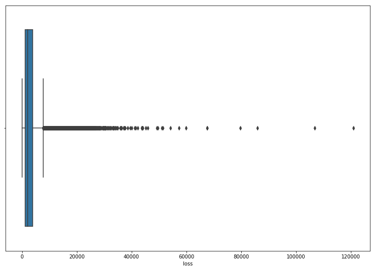

```python
plt.figure(figsize=(13,9))
sns.boxplot(instrain["loss"])
```

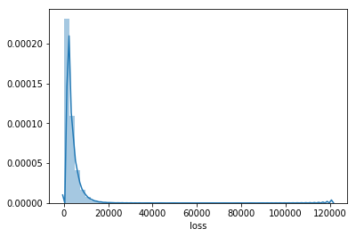

```python
sns.distplot(instrain["loss"])
```

observation

Here, we can see loss is highly right skewed data. This happened because there are many outliers in the data that we ca see from box plot. Lets apply log to see if we can get normal distribution

###### Applying logarithm on loss function

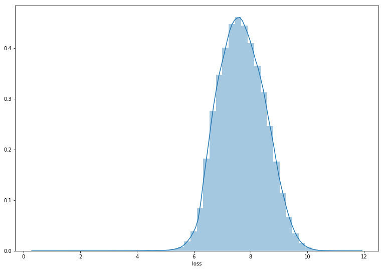

```python
plt.figure(figsize=(13,9))
sns.distplot(np.log1p(instrain["loss"]))
```

observation

we got normal distribution by applying logarithm on loss function Finally we got normal distribution, so we can train model using target feature as log of loss. This way we don't have to remove outliers.

```python
catCount = sum(str(x).isalpha() for x in instrain.iloc[1,:])
print("Number of categories: ",catCount)
```

```
Number of categories:  116
```

```python
instrain_id = instrain['id']
instest_id = instest['id']
```

```python
instrain_target = instrain["loss"]
```

###### Droping

```python
instrain.drop('id',axis=1,inplace=True)
instrain.drop('loss',axis=1,inplace=True)
instest.drop('id',axis=1,inplace=True)
```

###### Data type conversion

```python
num_cols=['cont1','cont2','cont3','cont4','cont5','cont6', 'cont7', 'cont8', 'cont9', 'cont10', 'cont11', 'cont12',
       'cont13', 'cont14']
cat_cols = instrain.columns.difference(num_cols)
```

```python
instrain[cat_cols]=instrain[cat_cols].astype('category')
instrain.dtypes
```

```
cat1      category
cat2      category
cat3      category
cat4      category
cat5      category
cat6      category
cat7      category
cat8      category
cat9      category
cat10     category
cat11     category
cat12     category
cat13     category
cat14     category
cat15     category
cat16     category
cat17     category
cat18     category
cat19     category
cat20     category
cat21     category
cat22     category
cat23     category
cat24     category
cat25     category
cat26     category
cat27     category
cat28     category
cat29     category
cat30     category
            ...
cat101    category
cat102    category
cat103    category
cat104    category
cat105    category
cat106    category
cat107    category
cat108    category
cat109    category
cat110    category
cat111    category
cat112    category
cat113    category
cat114    category
cat115    category
cat116    category
cont1      float64
cont2      float64
cont3      float64
cont4      float64
cont5      float64
cont6      float64
cont7      float64
cont8      float64
cont9      float64
cont10     float64
cont11     float64
cont12     float64
cont13     float64
cont14     float64
Length: 130, dtype: object
```

###### Convert categorical string values to numeric values

For train-data

```python
from sklearn.preprocessing import LabelEncoder
```

```python
for x in cat_cols:
    le = LabelEncoder()
    le.fit(instrain[x].unique())
    instrain[x] = le.transform(instrain[x])
```

```python
instrain.head(5)
```

|  | cat1 | cat2 | cat3 | cat4 | cat5 | cat6 | cat7 | cat8 | cat9 | cat10 | ... | cont5 | cont6 | cont7 | cont8 | cont9 | cont10 | cont11 | cont12 | cont13 | cont14 |
| --- | --- | --- | --- | --- | --- | --- | --- | --- | --- | --- | --- | --- | --- | --- | --- | --- | --- | --- | --- | --- | --- |
| 0 | 0 | 1 | 0 | 1 | 0 | 0 | 0 | 0 | 1 | 0 | ... | 0.310061 | 0.718367 | 0.335060 | 0.30260 | 0.67135 | 0.83510 | 0.569745 | 0.594646 | 0.822493 | 0.714843 |
| 1 | 0 | 1 | 0 | 0 | 0 | 0 | 0 | 0 | 1 | 1 | ... | 0.885834 | 0.438917 | 0.436585 | 0.60087 | 0.35127 | 0.43919 | 0.338312 | 0.366307 | 0.611431 | 0.304496 |
| 2 | 0 | 1 | 0 | 0 | 1 | 0 | 0 | 0 | 1 | 1 | ... | 0.397069 | 0.289648 | 0.315545 | 0.27320 | 0.26076 | 0.32446 | 0.381398 | 0.373424 | 0.195709 | 0.774425 |
| 3 | 1 | 1 | 0 | 1 | 0 | 0 | 0 | 0 | 1 | 0 | ... | 0.422268 | 0.440945 | 0.391128 | 0.31796 | 0.32128 | 0.44467 | 0.327915 | 0.321570 | 0.605077 | 0.602642 |
| 4 | 0 | 1 | 0 | 1 | 0 | 0 | 0 | 0 | 1 | 1 | ... | 0.704268 | 0.178193 | 0.247408 | 0.24564 | 0.22089 | 0.21230 | 0.204687 | 0.202213 | 0.246011 | 0.432606 |

5 rows × 130 columns

For test-data

```python
num_cols1=['cont1','cont2','cont3','cont4','cont5','cont6', 'cont7', 'cont8', 'cont9', 'cont10', 'cont11', 'cont12',
       'cont13', 'cont14']
cat_cols1 = instest.columns.difference(num_cols)
```

```python
instest[cat_cols1]=instest[cat_cols1].astype('category')
instest.dtypes
```

```
cat1      category
cat2      category
cat3      category
cat4      category
cat5      category
cat6      category
cat7      category
cat8      category
cat9      category
cat10     category
cat11     category
cat12     category
cat13     category
cat14     category
cat15     category
cat16     category
cat17     category
cat18     category
cat19     category
cat20     category
cat21     category
cat22     category
cat23     category
cat24     category
cat25     category
cat26     category
cat27     category
cat28     category
cat29     category
cat30     category
            ...
cat101    category
cat102    category
cat103    category
cat104    category
cat105    category
cat106    category
cat107    category
cat108    category
cat109    category
cat110    category
cat111    category
cat112    category
cat113    category
cat114    category
cat115    category
cat116    category
cont1      float64
cont2      float64
cont3      float64
cont4      float64
cont5      float64
cont6      float64
cont7      float64
cont8      float64
cont9      float64
cont10     float64
cont11     float64
cont12     float64
cont13     float64
cont14     float64
Length: 130, dtype: object
```

```python
for x in cat_cols1:
    le = LabelEncoder()
    le.fit(instest[x].unique())
    instest[x] = le.transform(instest[x])
```

```python
instest.head(6)
```

|  | cat1 | cat2 | cat3 | cat4 | cat5 | cat6 | cat7 | cat8 | cat9 | cat10 | ... | cont5 | cont6 | cont7 | cont8 | cont9 | cont10 | cont11 | cont12 | cont13 | cont14 |
| --- | --- | --- | --- | --- | --- | --- | --- | --- | --- | --- | --- | --- | --- | --- | --- | --- | --- | --- | --- | --- | --- |
| 0 | 0 | 1 | 0 | 0 | 0 | 0 | 0 | 0 | 1 | 0 | ... | 0.281143 | 0.466591 | 0.317681 | 0.61229 | 0.34365 | 0.38016 | 0.377724 | 0.369858 | 0.704052 | 0.392562 |
| 1 | 0 | 1 | 0 | 1 | 0 | 0 | 0 | 0 | 1 | 0 | ... | 0.836443 | 0.482425 | 0.443760 | 0.71330 | 0.51890 | 0.60401 | 0.689039 | 0.675759 | 0.453468 | 0.208045 |
| 2 | 0 | 1 | 0 | 1 | 1 | 0 | 1 | 0 | 1 | 1 | ... | 0.718531 | 0.212308 | 0.325779 | 0.29758 | 0.34365 | 0.30529 | 0.245410 | 0.241676 | 0.258586 | 0.297232 |
| 3 | 0 | 0 | 0 | 0 | 1 | 0 | 0 | 0 | 0 | 0 | ... | 0.397069 | 0.369930 | 0.342355 | 0.40028 | 0.33237 | 0.31480 | 0.348867 | 0.341872 | 0.592264 | 0.555955 |
| 4 | 1 | 0 | 0 | 0 | 0 | 1 | 0 | 0 | 0 | 0 | ... | 0.302678 | 0.398862 | 0.391833 | 0.23688 | 0.43731 | 0.50556 | 0.359572 | 0.352251 | 0.301535 | 0.825823 |
| 5 | 0 | 0 | 0 | 0 | 1 | 0 | 0 | 0 | 0 | 0 | ... | 0.643315 | 0.407351 | 0.390540 | 0.46477 | 0.46853 | 0.50556 | 0.607500 | 0.594646 | 0.250991 | 0.283976 |

6 rows × 130 columns

```python
print("Train shape",instrain.shape)
print("Test shape",instest.shape)
```

```
Train shape (188318, 130)
Test shape (125546, 130)
```

###### Normalization independent variables

```python
# normalize numeric variables using min- max- scaler
from sklearn import preprocessing
```

```python
num_train = instrain[instrain.columns[116:]]
num_test = instest[instest.columns[116:]]
```

```python
mm_scaler = preprocessing.MinMaxScaler().fit(num_train)
```

```python
# apply min-max-scaler
norm_train = mm_scaler.transform(num_train)
norm_test = mm_scaler.transform(num_test)
```

```python
#converting numberice to data frame
norm_train = pd.DataFrame(norm_train,columns=list(num_train.columns))
norm_test = pd.DataFrame(norm_test,columns=list(num_test.columns))
```

```python
norm_train.head()
```

|  | cont1 | cont2 | cont3 | cont4 | cont5 | cont6 | cont7 | cont8 | cont9 | cont10 | cont11 | cont12 | cont13 | cont14 |
| --- | --- | --- | --- | --- | --- | --- | --- | --- | --- | --- | --- | --- | --- | --- |
| 0 | 0.737375 | 0.284121 | 0.196416 | 0.788187 | 0.041163 | 0.716810 | 0.285393 | 0.088414 | 0.674426 | 0.839313 | 0.554715 | 0.580320 | 0.832028 | 0.804541 |
| 1 | 0.335545 | 0.854225 | 0.626632 | 0.562422 | 0.860732 | 0.432954 | 0.394501 | 0.489681 | 0.352841 | 0.441406 | 0.314495 | 0.343023 | 0.618460 | 0.187595 |
| 2 | 0.265823 | 0.414588 | 0.511420 | 0.077187 | 0.165012 | 0.281332 | 0.264420 | 0.048862 | 0.261906 | 0.326097 | 0.359217 | 0.350420 | 0.197802 | 0.894121 |
| 3 | 0.326489 | 0.643795 | 0.557931 | 0.253282 | 0.200881 | 0.435014 | 0.345649 | 0.109078 | 0.322710 | 0.446914 | 0.303703 | 0.296531 | 0.612031 | 0.635849 |
| 4 | 0.277360 | 0.184376 | 0.557931 | 0.381130 | 0.602287 | 0.168119 | 0.191194 | 0.011785 | 0.221848 | 0.213371 | 0.175796 | 0.172492 | 0.248701 | 0.380205 |

```python
norm_test.head()
```

|  | cont1 | cont2 | cont3 | cont4 | cont5 | cont6 | cont7 | cont8 | cont9 | cont10 | cont11 | cont12 | cont13 | cont14 |
| --- | --- | --- | --- | --- | --- | --- | --- | --- | --- | --- | --- | --- | --- | --- |
| 0 | 0.326489 | 0.345852 | 0.259423 | 0.290723 | 0.000000 | 0.461064 | 0.266716 | 0.505045 | 0.345185 | 0.382078 | 0.355403 | 0.346714 | 0.712181 | 0.320000 |
| 1 | 0.644411 | 0.719272 | 0.692082 | 0.990119 | 0.790428 | 0.477148 | 0.402212 | 0.640935 | 0.521259 | 0.607057 | 0.678538 | 0.664615 | 0.458621 | 0.042583 |
| 2 | 0.295238 | 0.854225 | 0.752456 | 0.303416 | 0.622589 | 0.202772 | 0.275418 | 0.081661 | 0.345185 | 0.306830 | 0.218066 | 0.213503 | 0.261426 | 0.176673 |
| 3 | 0.272708 | 0.790027 | 0.626632 | 0.228939 | 0.165012 | 0.362879 | 0.293233 | 0.219825 | 0.333852 | 0.316388 | 0.325451 | 0.317630 | 0.599065 | 0.565657 |
| 4 | 0.562287 | 0.345852 | 0.277115 | 0.668855 | 0.030653 | 0.392267 | 0.346406 | 0.000000 | 0.439286 | 0.508111 | 0.336562 | 0.328416 | 0.304885 | 0.971396 |

###### correlation graph

Lets draw a correlation graph so that we can remove multi colinearity it means the columns are Dependenig on each other so we should avoid it because what is the use of using same column twice.

lets check the correlation between features

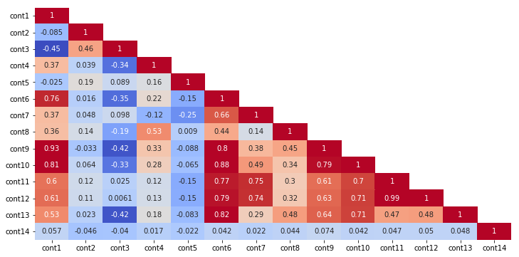

```python
matrix = num_train.corr()
f, ax = plt.subplots(figsize=(12, 6))
with sns.axes_style("white"):
    sns.heatmap(matrix,mask=np.triu(matrix,1),annot=True, vmax=.8,cbar=False,cmap="coolwarm");
```

observation

The cont11,count12 are highly correlated as expected from their relation so from these we ill use anyone of them.

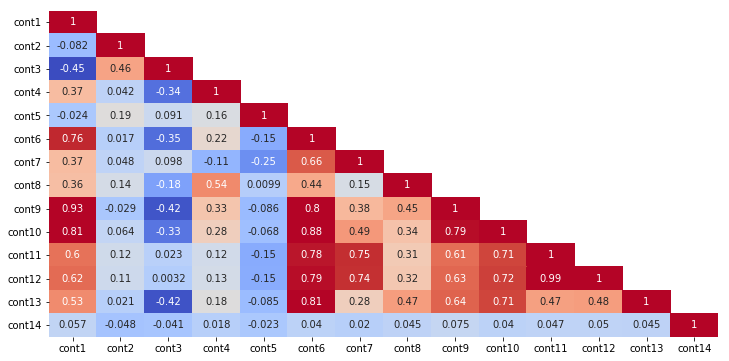

```python
matrix = norm_test.corr()
f, ax = plt.subplots(figsize=(12, 6))
with sns.axes_style("white"):
    sns.heatmap(matrix,mask=np.triu(matrix,1),annot=True, vmax=.8,cbar=False,cmap="coolwarm");
```

The cont11,count12 are highly correlated as expected from their relation so from these we ill use anyone of them.

###### Dropping Highly co-relacted column

```python
norm_train.drop(['cont11'],axis=1,inplace=True)
```

```python
norm_test.drop(['cont11'],axis=1,inplace=True)
```

```python
import warnings
warnings.filterwarnings('ignore')
```

###### Train test split

```python
from sklearn.model_selection import train_test_split
trainx,valx,trainy,valy = train_test_split(instrain,instrain_target,test_size=0.3,random_state=123)

print(trainx.shape,valx.shape,trainy.shape,valy.shape)
```

```
(131822, 130) (56496, 130) (131822,) (56496,)
```

### Lasso

```python
from sklearn.linear_model import Lasso
from sklearn.linear_model import LinearRegression
from sklearn.model_selection import train_test_split
```

```python
lasso = Lasso()
lasso.fit(trainx,trainy)
train_score=lasso.score(trainx,trainy)
val_score=lasso.score(valx,valy)
coeff_used = np.sum(lasso.coef_!=0)
```

```python
print("training score:", train_score)
print("val score: ", val_score)
print("number of features used: ", coeff_used)
```

```
training score: 0.4808267322887123
val score:  0.4825758267576019
number of features used:  91
```

Lasso with alpha(hyperparamete)

```python
lasso00001 = Lasso(alpha=0.0001)
lasso00001.fit(trainx,trainy)
```

```
Lasso(alpha=0.0001, copy_X=True, fit_intercept=True, max_iter=1000,
      normalize=False, positive=False, precompute=False, random_state=None,
      selection='cyclic', tol=0.0001, warm_start=False)
```

```python
train_score00001=lasso00001.score(trainx,trainy)
val_score00001=lasso00001.score(valx,valy)
coeff_used00001 = np.sum(lasso00001.coef_!=0)
```

```python
print("training score for alpha=0.0001:", train_score00001)
print("val score for alpha =0.0001: ", val_score00001)
print("number of features used: ", coeff_used00001)
```

```
training score for alpha=0.0001: 0.48210022845731526
val score for alpha =0.0001:  0.4835897521178057
number of features used:  130
```

###### LinearRegression

```python
import sklearn.metrics as sm
```

```python
lr = LinearRegression()
lr.fit(trainx,trainy)
lr_train_score=lr.score(trainx,trainy)
lr_val_score=lr.score(valx,valy)
```

```python
print ("LR training score:", lr_train_score)
print ("LR val score: ", lr_val_score)
```

```
LR training score: 0.48218641915525995
LR val score:  0.4835978071668429
```

```python
from sklearn.linear_model import LinearRegression
from sklearn import metrics

lin_regressor = LinearRegression()
lin_regressor.fit(trainx, trainy)
y_pred_train_LR = lin_regressor.predict(trainx)
y_pred_test_LR=lin_regressor.predict(valx)
print("R-squared value ---",metrics.r2_score(valy,y_pred_test_LR))
print("RMSE for Train ---",np.sqrt(metrics.mean_squared_error(trainy, y_pred_train_LR)))
print("RMSE for val ---",np.sqrt(metrics.mean_squared_error(valy, y_pred_test_LR)))
```

```
R-squared value --- 0.48359780716684286
RMSE for Train --- 2100.8788963671277
RMSE for val --- 2060.728367339508
```

```python
print('mape: ',np.mean(np.abs((trainy-y_pred_train_LR)/trainy)*100))
print('mape: ',np.mean(np.abs((valy-y_pred_test_LR)/valy)*100))
```

```
mape:  70.62473598514781
mape:  69.29978005356575
```

```python
print("LinearRegression:")
print("Mean absolute error =", round(sm.mean_absolute_error(valy, y_pred_test_LR), 2))
```

```
LinearRegression:
Mean absolute error = 1332.92
```

```
([4089773.4339774586,
  4198631.409993829,
  4102621.1803810713,
  4124557.459955714,
  4285788.176073195,
  4293459.265235249,
  4511823.252634865,
  4469825.531714087,
  4423876.436270036,
  4413692.137200761],
 [4341508.480633638,
  4272795.601742478,
  4257195.632559617,
  4250857.084618564,
  4248075.991076553,
  4247133.925887945,
  4250090.758831664,
  4248847.859579004,
  4247772.843300747,
  4246601.403957754])
```

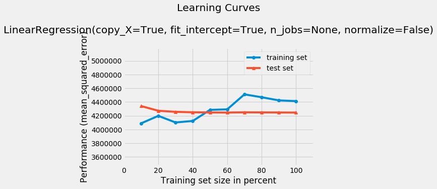

```python
from mlxtend.plotting import plot_learning_curves

plot_learning_curves(trainx, trainy, valx, valy, lin_regressor, scoring='mean_squared_error')
```

###### Multiple Linear regression with Square root transformations Applying square root on target variables of train and test

```python
train_sqrt=np.sqrt(trainy)
val_sqrt=np.sqrt(valy)
```

```python
from sklearn.linear_model import LinearRegression
from sklearn import metrics

lin_regressor = LinearRegression()
lin_regressor.fit(trainx, train_sqrt)
y_pred_train_LR = (lin_regressor.predict(trainx))**2
y_pred_val_LR=(lin_regressor.predict(valx))**2

print("R-squared value ---",metrics.r2_score(valy,y_pred_val_LR))
print("RMSE for Train ---",np.sqrt(metrics.mean_squared_error(train_sqrt, y_pred_train_LR)))
print("RMSE for Test ---",np.sqrt(metrics.mean_squared_error(test_sqrt, y_pred__LR)))
```

[output not shown]

```python
print('mape: ',np.mean(np.abs((trainy-y_pred_train_LR)/trainy)*100))
print('mape: ',np.mean(np.abs((valy-y_pred_val_LR)/valy)*100))
```

```
mape:  60.52087520750012
mape:  59.59939491355311
```

```python
print("Multiple Linear regression")
print("Mean absolute error =", round(sm.mean_absolute_error(valy, y_pred_val_LR), 2))
```

```
Multiple Linear regression
Mean absolute error = 1253.65
```

```
([219.38365361377177,
  221.1773103875479,
  219.97550855803127,
  219.6799322048427,
  221.4871738347977,
  222.00095805355858,
  223.1139622766101,
  222.8555724894948,
  221.90274318962375,
  222.07487547474307],
 [227.0700134939633,
  223.0989473506627,
  222.546566007092,
  222.2384299550814,
  222.08543224038667,
  222.0205561543288,
  221.99719119055825,
  221.95453874185392,
  221.94461491456417,
  221.86442086147852])
```

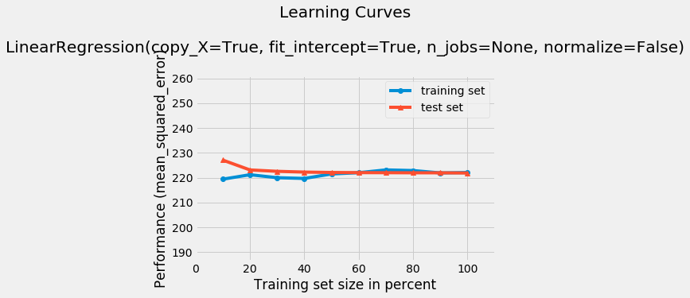

```python
from mlxtend.plotting import plot_learning_curves

plot_learning_curves(trainx, train_sqrt, valx, val_sqrt, lin_regressor, scoring='mean_squared_error')
```

###### Decision Tree regression with Square root transformation

```python
from sklearn.tree import DecisionTreeRegressor
dt=DecisionTreeRegressor(max_depth=8,min_samples_split=40,)
dt.fit(trainx, train_sqrt)
y_pred_train_dt = (dt.predict(trainx))**2
y_pred_val_dt=(dt.predict(valx))**2
```

```python
print('mape: ',np.mean(np.abs((trainy-y_pred_train_dt)/trainy)*100))
print('mape: ',np.mean(np.abs((valy-y_pred_val_dt)/valy)*100))
```

```
mape:  64.14063680130286
mape:  64.20361493259452
```

```python
print("Decision Tree regression")
print("Mean absolute error =", round(sm.mean_absolute_error(trainy, y_pred_train_dt), 2))
```

```
Decision Tree regression
Mean absolute error = 1294.88
```

```python
print("Decision Tree regression")
print("Mean absolute error =", round(sm.mean_absolute_error(valy, y_pred_val_dt), 2))
```

```
Decision Tree regression
Mean absolute error = 1322.3
```

```
([220.0997829521769,
  231.48752550619707,
  233.3071836278707,
  232.02019220830357,
  235.9874425231764,
  237.21395948623137,
  238.96994641303488,
  239.43992030294254,
  237.86070059123935,
  238.5232480295026],
 [272.47807203190473,
  262.21176917390414,
  255.3693611579709,
  253.1489937269796,
  251.24984036911744,
  250.0757342771895,
  249.12830589576535,
  250.871302105725,
  247.88274454286034,
  250.64095894512488])
```

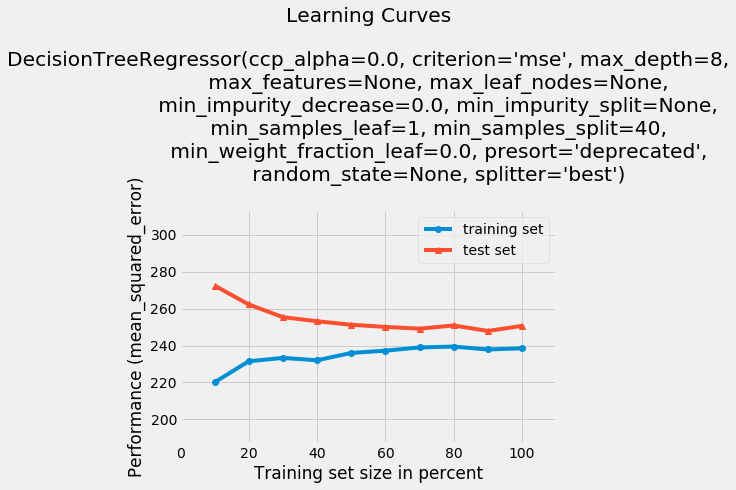

```python
from mlxtend.plotting import plot_learning_curves

plot_learning_curves(trainx, train_sqrt, valx, val_sqrt, dt, scoring='mean_squared_error')
```

###### GradientBoostingRegressor with Square root transformation

```python
from sklearn.ensemble import GradientBoostingRegressor
from sklearn.metrics import mean_squared_error
from sklearn.datasets import load_boston
from sklearn.metrics import mean_absolute_error
```

```python
gbm=GradientBoostingRegressor(max_depth=5,max_leaf_nodes=10,n_estimators=25)
gbm.fit(X=trainx, y=train_sqrt)
y_pred_train_gbm =(gbm.predict(trainx))**2
y_pred_val_gbm=(gbm.predict(valx))**2
```

```python
print('mape: ',np.mean(np.abs((trainy-y_pred_train_gbm)/trainy)*100))
print('mape: ',np.mean(np.abs((valy-y_pred_val_gbm)/valy)*100))
```

```
mape:  66.29598591705623
mape:  65.58509809170977
```

```python
print("GradientBoostingRegressor")
print("Mean absolute error =", round(sm.mean_absolute_error(trainy,y_pred_train_gbm ), 2))
```

```
GradientBoostingRegressor
Mean absolute error = 1314.39
```

```python
print("GradientBoostingRegressor")
print("Mean absolute error =", round(sm.mean_absolute_error(valy, y_pred_val_gbm), 2))
```

```
GradientBoostingRegressor
Mean absolute error = 1316.54
```

```
([235.51673798304998,
  237.9851916142725,
  237.75974450898144,
  237.02570690074413,
  240.340447180637,
  241.07802286689994,
  242.06753024372438,
  242.2429604746111,
  240.41087060554136,
  241.08660326562853],
 [242.4752351834663,
  241.9259378818063,
  242.43246733594415,
  241.5693032339941,
  242.90554880688063,
  242.5418412744762,
  242.96861068634118,
  243.0680953497277,
  242.14989894387966,
  242.1173484085562])
```

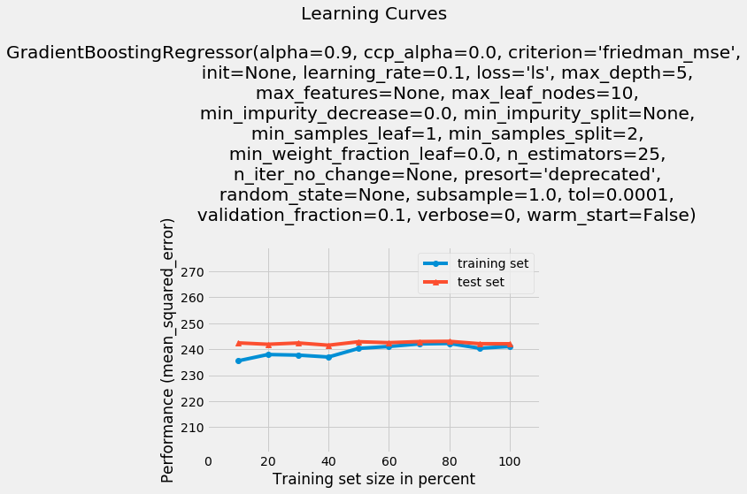

```python
plot_learning_curves(trainx, train_sqrt, valx, val_sqrt, gbm, scoring='mean_squared_error')
```

###### RandomForestRegressor with Square root transformation

```python
from sklearn.ensemble import RandomForestRegressor
rfr=RandomForestRegressor(max_depth=18,min_samples_leaf=3,min_samples_split=2,n_estimators=75)
rfr.fit(trainx,train_sqrt)
y_pred_train_rfr = (rfr.predict(trainx))**2
y_pred_val_rfr=(rfr.predict(valx))**2
```

```python
print('mape: ',np.mean(np.abs((trainy-y_pred_train_rfr)/trainy)*100))
print('mape: ',np.mean(np.abs((valy-y_pred_val_rfr)/valy)*100))
```

```
mape:  43.501813227003204
mape:  57.4224291407843
```

```python
print("RandomForestRegressor:")
print("Mean absolute error =", round(sm.mean_absolute_error(trainy, y_pred_train_rfr), 2))
```

```
RandomForestRegressor:
Mean absolute error = 862.73
```

```python
print("RandomForestRegressor")
print("Mean absolute error =", round(sm.mean_absolute_error(valy, y_pred_val_rfr), 2))
```

```
RandomForestRegressor
Mean absolute error = 1213.22
```

```python
imp=pd.DataFrame(rfr.feature_importances_,index=trainx.columns)
```

```python
imp.sort_values(by=0,ascending=False)
```

|  | 0 |
| --- | --- |
| cat80 | 3.305749e-01 |
| cont7 | 5.598568e-02 |
| cat79 | 5.338322e-02 |
| cat12 | 5.169855e-02 |
| cont2 | 4.138695e-02 |
| cont14 | 3.417234e-02 |
| cat57 | 3.415968e-02 |
| cat81 | 2.938328e-02 |
| cat101 | 2.671167e-02 |
| cat103 | 1.970471e-02 |
| cat111 | 1.636745e-02 |
| cat1 | 1.630586e-02 |
| cat100 | 1.597095e-02 |
| cont3 | 1.237913e-02 |
| cont8 | 1.164394e-02 |
| cont12 | 1.151025e-02 |
| cat112 | 1.122895e-02 |
| cat114 | 1.120746e-02 |
| cat72 | 1.111720e-02 |
| cont11 | 1.089686e-02 |
| cont6 | 1.045626e-02 |
| cont5 | 1.041061e-02 |
| cat53 | 1.033846e-02 |
| cont4 | 9.980005e-03 |
| cont1 | 9.937252e-03 |
| cont13 | 9.586898e-03 |
| cat110 | 8.295331e-03 |
| cont10 | 7.836019e-03 |
| cont9 | 7.513962e-03 |
| cat113 | 6.921564e-03 |
| ... | ... |
| cat78 | 2.179989e-04 |
| cat14 | 2.003004e-04 |
| cat17 | 1.902126e-04 |
| cat51 | 1.692554e-04 |
| cat18 | 1.563716e-04 |
| cat32 | 1.501251e-04 |
| cat42 | 1.371105e-04 |
| cat59 | 1.185303e-04 |
| cat47 | 1.042906e-04 |
| cat46 | 8.925674e-05 |
| cat33 | 8.250867e-05 |
| cat67 | 4.413336e-05 |
| cat61 | 3.808571e-05 |
| cat21 | 3.024820e-05 |
| cat60 | 2.921192e-05 |
| cat34 | 2.678702e-05 |
| cat56 | 2.471488e-05 |
| cat48 | 1.692447e-05 |
| cat58 | 8.897941e-06 |
| cat35 | 6.551498e-06 |
| cat55 | 6.076577e-06 |
| cat20 | 1.934271e-07 |
| cat63 | 0.000000e+00 |
| cat15 | 0.000000e+00 |
| cat68 | 0.000000e+00 |
| cat62 | 0.000000e+00 |
| cat22 | 0.000000e+00 |
| cat64 | 0.000000e+00 |
| cat70 | 0.000000e+00 |
| cat69 | 0.000000e+00 |

130 rows × 1 columns

```python
imp=imp[imp[0]<0.007]
```

```python
imp
```

|  | 0 |
| --- | --- |
| cat2 | 2.460623e-03 |
| cat3 | 6.856621e-04 |
| cat4 | 1.886198e-03 |
| cat5 | 1.869022e-03 |
| cat6 | 1.602732e-03 |
| cat7 | 5.654840e-04 |
| cat8 | 4.093465e-04 |
| cat9 | 1.507514e-03 |
| cat10 | 1.052636e-03 |
| cat11 | 9.094783e-04 |
| cat13 | 1.085136e-03 |
| cat14 | 2.003004e-04 |
| cat15 | 0.000000e+00 |
| cat16 | 5.614514e-04 |
| cat17 | 1.902126e-04 |
| cat18 | 1.563716e-04 |
| cat19 | 3.399678e-04 |
| cat20 | 1.934271e-07 |
| cat21 | 3.024820e-05 |
| cat22 | 0.000000e+00 |
| cat23 | 1.523559e-03 |
| cat24 | 4.165426e-04 |
| cat25 | 1.130229e-03 |
| cat26 | 2.074727e-03 |
| cat27 | 2.563666e-03 |
| cat28 | 5.628889e-04 |
| cat29 | 4.969413e-04 |
| cat30 | 2.336052e-04 |
| cat31 | 8.438191e-04 |
| cat32 | 1.501251e-04 |
| ... | ... |
| cat77 | 8.745830e-04 |
| cat78 | 2.179989e-04 |
| cat82 | 3.113283e-03 |
| cat83 | 2.459714e-03 |
| cat84 | 1.434810e-03 |
| cat85 | 2.305167e-04 |
| cat86 | 2.295837e-04 |
| cat87 | 4.550960e-03 |
| cat88 | 4.015027e-04 |
| cat89 | 5.784030e-04 |
| cat90 | 6.669259e-04 |
| cat91 | 3.985945e-03 |
| cat92 | 2.338274e-03 |
| cat93 | 1.734511e-03 |
| cat94 | 1.906290e-03 |
| cat95 | 1.239962e-03 |
| cat96 | 7.618120e-04 |
| cat97 | 1.725873e-03 |
| cat98 | 5.472222e-04 |
| cat99 | 1.454023e-03 |
| cat102 | 1.195579e-03 |
| cat104 | 1.356768e-03 |
| cat105 | 3.748881e-03 |
| cat106 | 2.381058e-03 |
| cat107 | 3.287666e-03 |
| cat108 | 2.351331e-03 |
| cat109 | 1.952078e-03 |
| cat113 | 6.921564e-03 |
| cat115 | 3.033726e-03 |
| cat116 | 5.836701e-03 |

101 rows × 1 columns

```python
imp=pd.array(imp.index)
```

```python
trainx.drop(imp,axis=1,inplace=True)
```

```python
valx.drop(imp,axis=1,inplace=True)
```

###### GradientBoostingRegressor

```python
from sklearn.ensemble import GradientBoostingRegressor

gbm=GradientBoostingRegressor()
gbm.fit(trainx, trainy)
```

```
GradientBoostingRegressor(alpha=0.9, ccp_alpha=0.0, criterion='friedman_mse',
                          init=None, learning_rate=0.1, loss='ls', max_depth=3,
                          max_features=None, max_leaf_nodes=None,
                          min_impurity_decrease=0.0, min_impurity_split=None,
                          min_samples_leaf=1, min_samples_split=2,
                          min_weight_fraction_leaf=0.0, n_estimators=100,
                          n_iter_no_change=None, presort='deprecated',
                          random_state=None, subsample=1.0, tol=0.0001,
                          validation_fraction=0.1, verbose=0, warm_start=False)
```

```python
y_test_pred_gbm = gbm.predict(trainx)
```

```python
print("GradientBoostingRegressor:")
print("Mean absolute error =", round(sm.mean_absolute_error(trainy, y_test_pred_gbm), 2))
```

```
GradientBoostingRegressor:
Mean absolute error = 1252.37
```

```python
y_test_pred_gbm1 = gbm.predict(valx)
```

```python
print("GradientBoostingRegressor:")
print("Mean absolute error =", round(sm.mean_absolute_error(valy, y_test_pred_gbm1), 2))
```

```
GradientBoostingRegressor:
Mean absolute error = 1267.0
```

```python
y_test_pred_gbm1
```

```
array([1151.52907356, 1849.08747178, 2273.82912236, ..., 6188.98706422,
       1961.9762641 , 5107.6197558 ])
```

```python
y_test_pred_gbm1.shape
```

```
(56496,)
```

```python
instest_id
```

```
0              4
1              6
2              9
3             12
4             15
5             17
6             21
7             28
8             32
9             43
10            46
11            50
12            54
13            62
14            70
```

[output cut: 47 more lines]

```python
final_set = pd.DataFrame(instest_id)
```

```python
final_set.head()
```

|  | id |
| --- | --- |
| 0 | 4 |
| 1 | 6 |
| 2 | 9 |
| 3 | 12 |
| 4 | 15 |

```python
final_set['loss'] = pd.Series(y_test_pred_gbm1)
```

```python
final_set.head()
```

|  | id | loss |
| --- | --- | --- |
| 0 | 4 | 1151.529074 |
| 1 | 6 | 1849.087472 |
| 2 | 9 | 2273.829122 |
| 3 | 12 | 4699.517673 |
| 4 | 15 | 8883.102124 |

```python
final_set.to_csv('submission.csv',index=False,sep=",")
```